# Data Visualization Project

Faith Gibson

# Data Visualization Project

## Objectives for this project

To complete this project you’ll need to do a few things within this file. As you go through the notebook, you will have further instruction on how to complete these objectives.

1. Go through this notebook, reading along.
2. Fill in empty or incomplete code chunks when prompted to do so.
3. Run each code chunk as you come across it by clicking the tiny green triangles at the right of each chunk. You should see the code chunks print out various output when you do this.
4. At the very top of this file, put your own name in the `author:` place. Currently it says `"DataTrail Team"`. Be sure to put your name in quotes.
5. In the `Conclusions` section, write up responses to each of these questions posed here.
6. When you are satisfied with what you’ve written and added to this document you’ll need to save it. In the menu, go to `File` > `Save`. Now the `nb.html` output resulting file will have your new output saved to it.
7. Open up the resulting `airbnb_project.nb.html` file and click `View in Web Browser`. Does it look good to you? Did all the changes appear here as you expected.
8. Upload your `Rmd` and your `nb.html` files to your assignment folder (this is something that will be dependent on what your instructors have told you – or if you are taking this on your own, just collect these projects in one spot, preferably a Google Drive)!
9. Pat yourself on the back for finishing this project!

## The goal of this analysis

What kind of variables can have an effect on the overall price of an Airbnb rental? (ie. location, room type, etc.)

## Set up directories

Here we are going to make a `data` directory if it doesn’t already exist.

```r
if (!dir.exists("data")) {
  dir.create("data")
}
```

## Get the data

The data we’ll be using for this part of the project are about and can be downloaded from here: https://github.com/rfordatascience/tidytuesday/blob/master/data/2023/2023-01-24/readme.md

First, we’ll read the data in from our `data/raw` directory. Use the `read_csv` function to do this. Call this new data frame `airbnb_df`.

```r
airbnb_df <- readr::read_csv("data/raw/Airbnb_Open_Data.csv")
```

Use this chunk to do some exploring of this dataset to get an idea of what kind of information is here.

```r
summary("airbnb_df")
```

```
##    Length     Class      Mode
##         1 character character
```

```r
head(airbnb_df)
```

```
## # A tibble: 6 × 26
##        id NAME                      `host id` host_identity_verified `host name`
##     <dbl> <chr>                         <dbl> <chr>                  <chr>
## 1 1001254 Clean & quiet apt home b…   8.00e10 unconfirmed            Madaline
## 2 1002102 Skylit Midtown Castle       5.23e10 verified               Jenna
## 3 1002403 THE VILLAGE OF HARLEM...…   7.88e10 <NA>                   Elise
## 4 1002755 <NA>                        8.51e10 unconfirmed            Garry
## 5 1003689 Entire Apt: Spacious Stu…   9.20e10 verified               Lyndon
## 6 1004098 Large Cozy 1 BR Apartmen…   4.55e10 verified               Michelle
## # ℹ 21 more variables: `neighbourhood group` <chr>, neighbourhood <chr>,
## #   lat <dbl>, long <dbl>, country <chr>, `country code` <chr>,
## #   instant_bookable <lgl>, cancellation_policy <chr>, `room type` <chr>,
## #   `Construction year` <dbl>, price <chr>, `service fee` <chr>,
## #   `minimum nights` <dbl>, `number of reviews` <dbl>, `last review` <chr>,
## #   `reviews per month` <dbl>, `review rate number` <dbl>,
## #   `calculated host listings count` <dbl>, `availability 365` <dbl>, …
```

### Clean the data

Use the `janitor::clean_names` function to clean up some of these column names.

```r
airbnb_df <- airbnb_df %>% janitor::clean_names()
```

### Fix `neighbourhood_group` variable

Take a look at the `neighbourhood_group` variable. Try to summarize how many different neighborhood groups there are using the `summary()` function.

```r
summary("airbnb_df$neighborhood_group")
```

```
##    Length     Class      Mode
##         1 character character
```

You will find that this variable is a character, so we will need to check it as a factor to get meaningful information about the groups here. Thus run the `summary` function on a factor version of the `neighborhood_group` data, but don’t yet change the variable to be a factor.

```r
summary(as.factor(airbnb_df$neighbourhood_group))
```

```
##         Bronx       brookln      Brooklyn      manhatan     Manhattan
##          2712             1         41842             1         43792
##        Queens Staten Island          NA's
##         13267           955            29
```

You’ll notice there’s some typos here `brookln` and `manhatan`. Fix these typos in this dataset by whatever method you find most intuitive. After you have fixed the typos, make sure that you coerce `neighbourhood_group` as a factor.

```r
airbnb_df <- airbnb_df %>%
  mutate(neighbourhood_group = recode(neighbourhood_group, brookln = "Brooklyn", manhatan = "Manhattan")) %>%
  mutate(neighbourhood_group = as.factor(neighbourhood_group))
```

Re-run `summary()` on the `neighbourhood_group` to see if your code successfully fixed these misspellings.

```r
summary(airbnb_df$neighbourhood_group)
```

```
##         Bronx      Brooklyn     Manhattan        Queens Staten Island
##          2712         41843         43793         13267           955
##          NA's
##            29
```

### Fix numeric data

The `service_fee` and `price` columns are really numeric data but are being treated as characters because there are `$` and `,` included.

We’ll need to get rid of these. **Hint** use this kind of code: `stringr::str_remove(service_fee, "\\$|,")` within a mutate to get rid of the dollar signs. After you get rid of the dollar signs from both `service_fee` and `price`, coerce both of these variables to be numeric.

```r
airbnb_df <- airbnb_df %>%
  mutate(service_fee = stringr::str_remove(service_fee, "\\$|,")) %>%
  mutate(price = stringr::str_remove(price, "\\$|,")) %>%
  mutate(service_fee = as.numeric(service_fee)) %>%
  mutate(price = as.numeric(price))
```

Use summary to see if `price` and `service_fee` are now appropriately numeric data.

```r
summary(airbnb_df$price)
```

```
##    Min. 1st Qu.  Median    Mean 3rd Qu.    Max.    NA's
##    50.0   288.0   524.0   524.7   759.0   999.0   18150
```

```r
summary(airbnb_df$service_fee)
```

```
##    Min. 1st Qu.  Median    Mean 3rd Qu.    Max.    NA's
##      10      68     125     125     183     240     273
```

## Plot the data

Let’s make a series of plots that explore how the price of an airbnb may be related to the other variables in this set.

To refresh your memory, a basic ggplot code looks like this:

```
DATA_FRAME %>%
  ggplot(aes(VARIABLE, VARIABLE, color = OPTIONAL_VARIABLE)) +
  geom_PLOT_TYPE()
```

We recommend keeping the ggplot2 cheatsheet handy while you are going through this project: https://www.rstudio.com/resources/cheatsheets/

### Scatter plot

Now make a scatter plot that explores if `price` is related to one of the other numeric variables in the dataset.

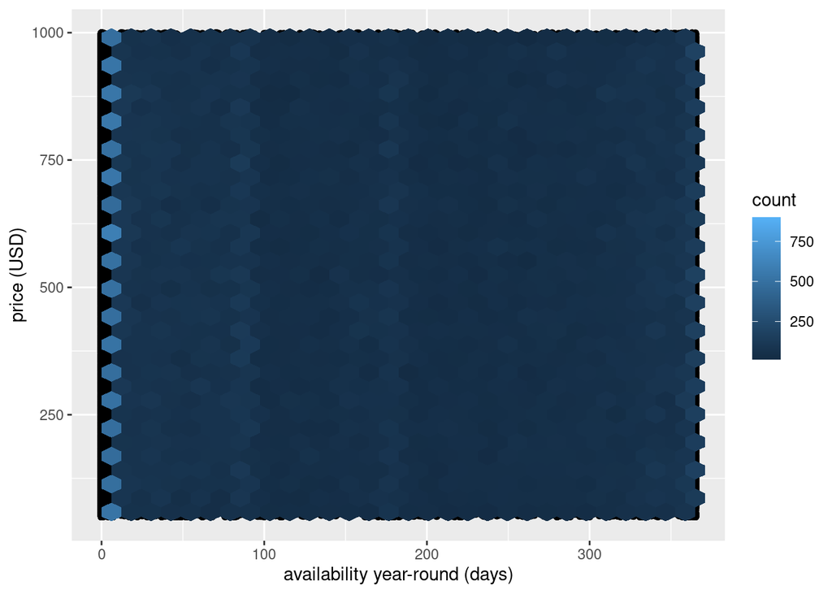

```r
airbnb_df %>%
  ggplot(aes(availability_365, price)) +
  geom_point() +
  stat_binhex() +
  xlim(0, 365) +
  xlab("availability year-round (days)") +
  ylab("price (USD)")
```

### Violin plot

Make a violin plot for the price distribution of different neighborhood groups.

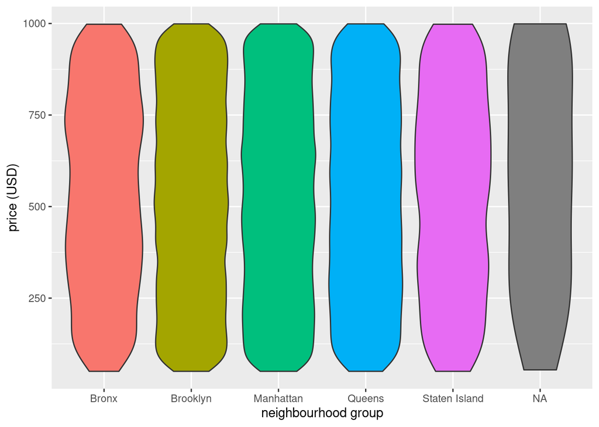

```r
airbnb_df %>%
  ggplot(aes(neighbourhood_group, price, fill = neighbourhood_group)) +
  geom_violin() +
  xlab("neighbourhood group") +
  ylab("price (USD)") +
  theme(legend.position = "none")
```

### Barplot

Now make a plot that explores if there’s a particular `room_type` that has a higher price than others. You may choose to summarize the `price` by the `room_type`. Hint: you may need to `group_by` a variable.

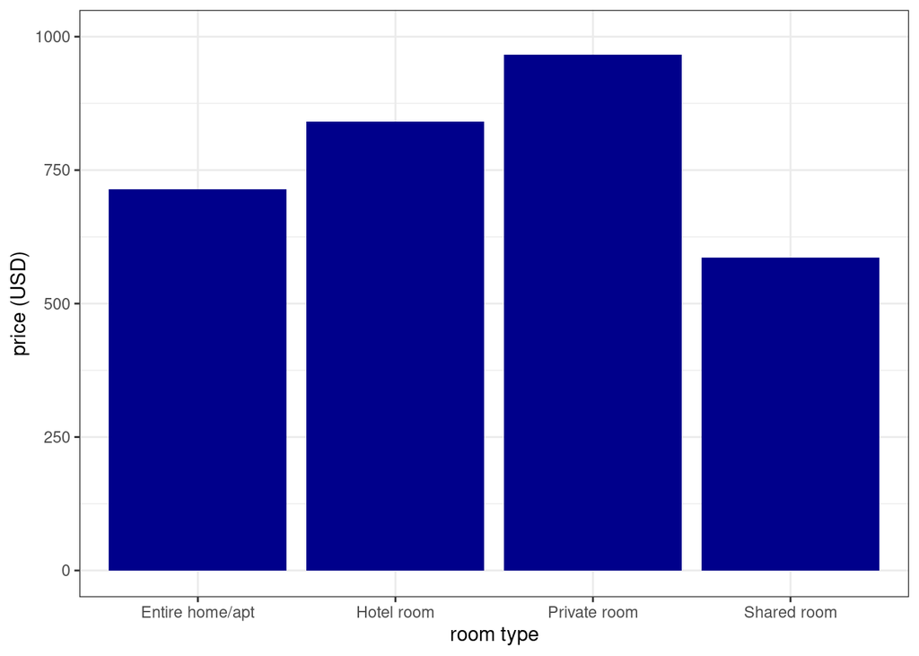

```r
airbnb_df %>%
  group_by(room_type) %>%
  summarise(price) %>%
  ggplot(aes(room_type, price)) +
  geom_bar(stat = 'identity', fill = "blue4") +
  theme_bw() +
  ylim(0, 1000) +
  xlab("room type") +
  ylab("price (USD)")
```

### Your choice plot!

Make one more plot that is completely your choice about what variables you’d like to see the relationships of.

See http://r-statistics.co/Top50-Ggplot2-Visualizations-MasterList-R-Code.html for inspiration and ideas.

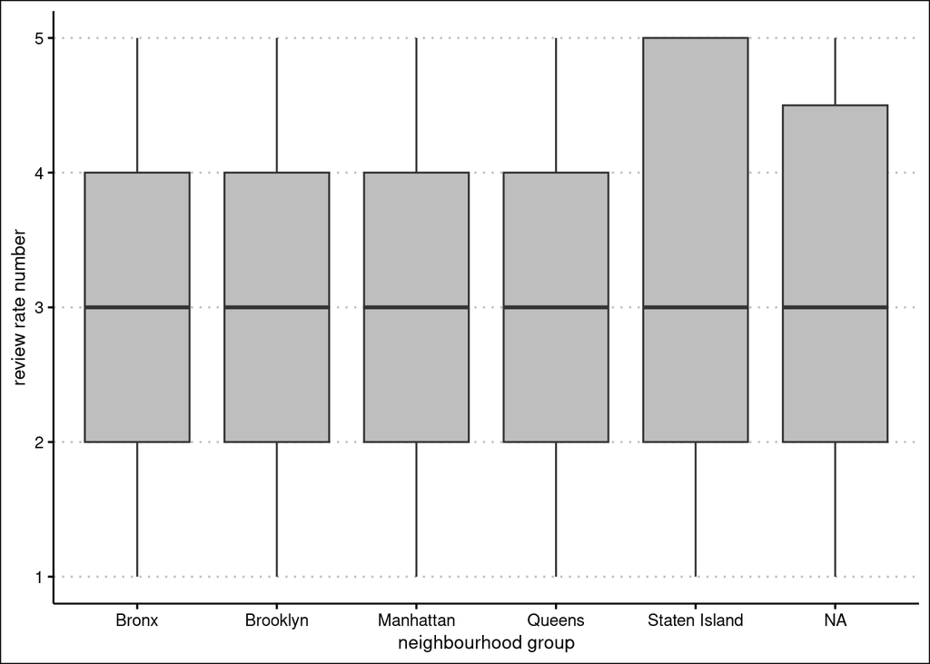

```r
airbnb_df %>%
  ggplot(aes(neighbourhood_group, review_rate_number)) +
  geom_boxplot(fill = "grey") +
  xlab("neighbourhood group") +
  ylab("review rate number") +
  theme_clean()
```

### Conclusion

```r
# feeling burned out. this one might not be as good as my previous work
# apologies in advance
```

Write up your thoughts about this data science project here and answer the following questions:

**- What did we find out about our questions?**

We found that there aren’t many variables that seem to have an effect on the total rental price of an Airbnb.

**- How did we explore our questions?**

We explored our question by generating multiple geoms of differing types, using different variables to explore how they are possibly related to the price to rent. Said geoms included a scatter plot (overlaid with hexagonal binning), violin plot, bar plot, and a box plot.

**- What did our explorations show us?**

**- What follow up data science questions arise for you regarding this Airbnb dataset now that we’ve explored it some?**

Some other variables I was interested in looking at, regarding their relationship with price, were the construction year, minimum nights required per stay, and the number of reviews received per month. I’d also be interested in looking into whether properties with lengthy rule lists tended to have stricter cancellation policies or not.

## Print out session info

Session info is a good thing to print out at the end of your notebooks so that you (and other folks) referencing your notebooks know what software versions and libraries you used to run the notebook.

[session information not shown]